# Finalizing the dye hit grid

We have called all hits for all screens. Before making the final figure, we should plot everything that was called as a hit (and not a hit), to double-check our calls and catch any errors. These will also serve a supplemental figures, likely

Also, we need to sort through the hits called as a “2”, which means “some protein-responsive behavior, but not a cannonical, at-the-correct-temperature DSF-like transition. Some of these can be represented in the main heatmap as”alternative detections" but we want to make sure we don’t put any trash in that category…

```r
library(grid) # arranging the plots for saving
library(phytools) # used to create the hierarchical clustering graph, and define the dye hit order
library(tidyverse)
```

Oringinally, I was going to re-do the hierarchical clustering to include the AW dyes. But they clustered strangely (probably need to figure out what was different in th clustering method) So I went forward without the AW dyes, since there were only three, and they had only been screened against the 715 proteins. Likely we will put them back in after the final clustering and likely a bit more protein screening. But this code should work with those updates.

Read in the hierarchical clustering of the dyes from https://chemminetools.ucr.edu/tools/list_jobs/

```r
clean_dye_names <- function( vec ) {
  vec %>%
    gsub( "S.O.500X|SO500X", "SO5X", . ) %>% # low concentration SYPRO
    gsub( "S.O.5000X", "SO50X", . ) %>% # high concentration SYPRO, from old screens
    str_replace_all(. , "-", "") # remove hyphens from the names
}

# these dyes include all of the ones for which we have both screening data and structures
dye_order <- read.newick(file = "output_ignore/dye_descriptors/clusteringtree (4).tre")$tip.label %>%
              clean_dye_names() %>%
              factor(. , levels = .) %>%
              tibble(dye_order = . ,
                     order_numeric = c(1:length(dye_order))
                     )
```

```
Read 1 item
```

```r
dye_order %>% head()
```

| dye_order | order_numeric |
| --- | --- |
| MWC050 | 1 |
| MWC045 | 2 |
| MWC022 | 3 |
| MWC004 | 4 |
| MWC051 | 5 |
| MWC009 | 6 |

Read in the dye hit grid. In this hit grid, the dyes which were not screened are not distinguished from ones which were screend but not a hit. Differentiating not screened and screened,not hit happens in the next code chunk.

```r
# these are screens which we have processed but aren't going to put in the published data for various reasons.
remove_screens <- c("Ds00009--0p01_TritonX100_in_P1", "Ds00011--Tau_P301S", "Exp0618--OLF", "Exp0707--DDM_buffer", "Exp0729--Tau_mi_diamond_10uM", "Exp0730--Tau_ms_diamond", "Exp0734--Tau_mi_diamond_1uM") # screens which we aren't going to consider in the paper

# read in and label all dye hits
dye_hits_raw <- read_csv("output_ignore/hit_definitions/Exp0810--20200404_all_screen_hits_v3.csv") %>%
            pivot_longer(-c(comments, dye, `buffer too bad?`, reject_buffer, maxed_out, protein_sensitive), names_to = "screen", values_to = "value")  %>%
            mutate(dye_f = factor(.$dye, levels = dye_order$dye_order )) %>%
            filter(! screen %in% remove_screens) %>%
            mutate_at("value", gsub, pattern = 1, replacement = 10) %>%
            mutate_at("value", gsub, pattern = 2, replacement = 5) %>%
            mutate_at("value", as.numeric) %>%
            mutate_at("screen", gsub, pattern = "NHR32LBD", replacement = "NHR23LBD") %>%
            filter(! dye %in% c("SO5X", "SO50X")) %>% # keep only the "SYPRO" definition, which combines any SYPRO concentration
            filter(! dye %in% c("DMSO", "AW131", "AW132", "AW134"))# remove the DMSO and SYPRO columns
dye_hits_raw %>% head()
```

| comments | dye | buffer too bad? | reject_buffer | maxed_out | protein_sensitive | screen | value | dye_f |
| --- | --- | --- | --- | --- | --- | --- | --- | --- |
| 0 | A001 | 0 | FALSE | FALSE | FALSE | Exp0521--NHR23LBD | 0 | A001 |
| 0 | A001 | 0 | FALSE | FALSE | FALSE | Ds00010--Hsp72_SBD | 0 | A001 |
| 0 | A001 | 0 | FALSE | FALSE | FALSE | Exp0468--eIF2B_no_ISIB | 0 | A001 |
| 0 | A001 | 0 | FALSE | FALSE | FALSE | Exp0469--eIF2B_with_ISRIB | 0 | A001 |
| 0 | A001 | 0 | FALSE | FALSE | FALSE | Exp0486--Jdomain | 0 | A001 |
| 0 | A001 | 0 | FALSE | FALSE | FALSE | Exp0497--Hsp60 | 10 | A001 |

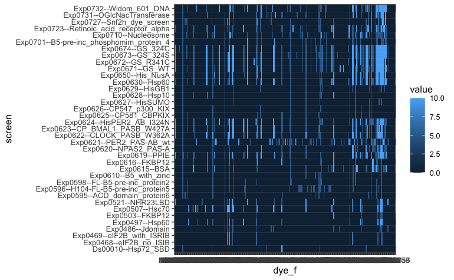

```r
# quick plot to make sure the results look ok
dye_hits_raw %>%
  ggplot(aes(x = screen, y = dye_f, fill = value), color = NA) +
  geom_tile() +
  theme_bw() +
  coord_flip()
```

Determine which dyes were screened against each protein

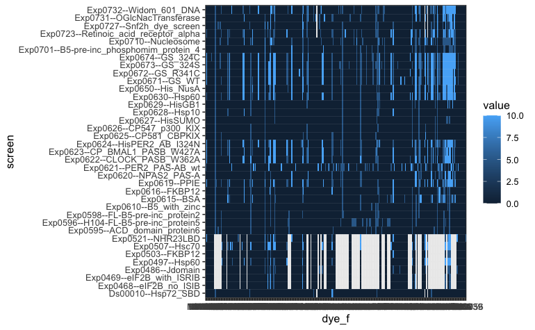

```r
layouts_per_screen <- read_csv("output_ignore/hit_definitions/Exp0810--layouts_to_screens.csv")
dyes_in_screen <- read_csv("output_ignore/hit_definitions/Exp0810--all_layouts.csv") %>%
                    pivot_longer(-plate, names_to = "column", values_to = "dye") %>%
                    mutate_at("dye", clean_dye_names) %>%
                    mutate_at("dye", gsub, pattern = "SO50X", replacement = "SYPRO") %>%
                    filter(! dye %in% c("DMSO", "AW131", "AW132", "AW134")) %>% # remove the DMSO and SYPRO columns
                    filter( dye %in% dye_hits$dye ) %>%
                    rename(daughter = "plate") %>%
                    full_join(layouts_per_screen, by = "daughter") %>%
                    rename(screen = "Screen") %>%
                    mutate("tested_dye" = rep(1, times = nrow(.)) ) %>%
                    select(-c(column, daughter)) %>%
                    group_by(screen) %>%
                    distinct(dye, .keep_all = TRUE) %>% # remove the duplicate dyes which result from the layouts in which dyes were screened at multiple concentrations
                    ungroup() %>%
                    pivot_wider(id_cols = screen, names_from = dye, values_from = tested_dye) %>%
                    mutate(SYPRO = rep(1, times = nrow(.))) %>% # SYPRO was always screened %>%
                    pivot_longer(-screen, names_to = "dye", values_to = "tested",values_drop_na = FALSE)
#dyes_in_screen %>% head()


dye_hits <- dyes_in_screen %>%
              full_join(dye_hits_raw, by = c("screen", "dye")) %>%
              filter( tested == 1 ) %>%
              filter( screen %in% dye_hits$screen)

ggplot(dye_hits, aes(x = screen, y = dye_f, fill = value), color = NA) +
              geom_tile() +
              theme_bw() +
              #scale_fill_viridis_c()+
             # dsfworld_default +
              coord_flip()
```

```r
pdf("test_layouts.pdf", height = 11, width = 8.5, paper = "letter")
grid.newpage()
pushViewport(viewport(layout = grid.layout(3, 15))) #
vplayout <- function(x, y) viewport(layout.pos.row = x, layout.pos.col = y)
print(a, vp = vplayout(1, 1:15))  # key is to define vplayout
print(b, vp = vplayout(2, 1:3))
print(c, vp = vplayout(3, 2:10))



## Create a graphical object g here
#vplayout
## Stop writing to the PDF file
dev.off()
```

```r
# hits_filtered <- dyes_in_screen %>%
#                   full_join(dye_hits, by = c("screen", "dye")) %>%
#                   filter( tested == 1 ) %>%
#                   filter( screen %in% dye_hits$screen)

# for a given protein, determine how many hit dyes are present in each
facet_no_y_theme <- theme( # for the first hit-calling plot, the most austere
  text = element_text(size = 8),
  axis.title = element_blank(), # don't label the axes
  axis.text.x = element_text(angle = 45), # don't label the numbers on the axes
  axis.ticks = element_blank(), # dont have ticks
  #legend.position = "right", # put a legent on the right of the plot
  legend.position = "none", # put a legent on the right of the plot
  plot.title = element_text(lineheight=.8, face="bold", size = 12), # have a title
  panel.grid.minor = element_blank(),
  panel.grid.major = element_blank(),
  strip.background = element_blank(),
  panel.spacing.x = unit(0.1, "lines"),
  panel.spacing.y = unit(0.1, "lines"),
  aspect.ratio = 1,
    plot.margin = margin(0, 0, 0, 0, "cm")
)

facet_wrap_two_conc <- function(df_melt, title, ncol_set) {
  p <- ggplot(df_melt, aes(x = Temperature, # temperature on X
                           y = value, # RFU on y
                           color = channel_f, # colored by the state
                           linetype = type,
                           group = well_channel_type # group means series, as in, this defines the unique data sets
  )) +
    geom_line(size = 0.3, alpha = 0.8) + # change the line type depending on the dye concentration # linetype = df_melt$conc #
    facet_wrap(~dye, scales = "free", ncol = ncol_set) +
    #labs(title = title, color = "Channel") +
    theme_bw() +
    scale_color_manual( values = c("Cy5.5" = "#67000d", "Cy5" = "#a50f15", "ROX" = "#ef3b2c", "TAMRA" = "#f16913", "JOE" = "#74c476", "FAM" = "#2171b5")) +
    scale_linetype_manual(values = c("dashed", "solid")) +
    facet_no_y_theme

  p # return the plot
}

get_dims <- function( ndyes ) {
  nd_length <- ndyes %>% length()

  list(
    total_dyes  = nd_length,
    ncol = if (nd_length < 15 ) { nd_length } else { 15 },
    nrow = ceiling( nd_length/15)
  )

}

make_total_dims <- function( dim10, dim5, dim0 ) {
  total_rows <- dim10$nrow + dim5$nrow + dim0$nrow + 3 # for margins and a title
  ncols <- max( c(dim10$ncol, dim5$ncol, dim0$ncol)) + 2 # for margins

  list(total_rows = total_rows, # for margins and a title
       total_cols = ncols,

       hits10_cols = c(2:(dim10$ncol+1)), # start at 2
       hits10_rows = c(2:(dim10$nrow+1)), # start at 2

       hits5_cols = c(2:(dim5$ncol+1)),  # start at 2
       hits5_rows = c((2+dim10$nrow):((1+dim10$nrow)+dim5$nrow)),

       hits0_cols = c(2:(dim0$ncol+1)),  # start at 2
       hits0_rows = c((total_rows-dim0$nrow-1):(total_rows-1)))
}

make_screen_summary <- function(path_to_data, screen_name, hits_filtered, ncol_set) {
  df_raw <- readRDS(path_to_data)

  hits <- hits_filtered %>% filter(screen == screen_name, tested == 1)

  hits10 <- hits %>%  filter(value == 10 ) %>% .$dye
  hits5 <- hits %>% filter(value == 5 ) %>% .$dye
  hits0 <- hits %>% filter(value == 0 ) %>% .$dye

  dims <- make_total_dims( get_dims(hits10),
                           get_dims(hits5),
                           get_dims(hits0)
                           )

    p10 <- df_raw %>%
          filter(dye %in% hits10)  %>%
          unite("well_channel_type", c(well, channel, type), remove = FALSE) %>%
          facet_wrap_two_conc("Hits", ncol_set)

    p5 <- df_raw %>%
          filter(dye %in% hits5)  %>%
          unite("well_channel_type", c(well, channel, type), remove = FALSE) %>%
          facet_wrap_two_conc("Protein sensitive, not a hit", ncol_set)

    p0 <- df_raw %>%
          filter(dye %in% hits0)  %>%
          unite("well_channel_type", c(well, channel, type), remove = FALSE) %>%
          facet_wrap_two_conc("Not a hit", ncol_set)

pdf_name <- paste0("output_ignore/individual_processed_screens/hits_sorted/", screen_name, "_hits_sorted.pdf")
pdf(pdf_name, height= dims$total_rows+4, width = dims$total_cols+3)
grid.newpage()
pushViewport(viewport(layout = grid.layout(dims$total_rows+4, dims$total_cols)))
#pushViewport(viewport(layout = grid.layout(3+3, dims$total_cols)))
vplayout <- function(x, y) viewport(layout.pos.row = x, layout.pos.col = y)
grid.text(paste0(" \n  ", screen_name), vp = vplayout(1,3), hjust = c(0,0,0), gp = gpar(fontsize = 35))

grid.text("\n \n  Hit", vp = vplayout(2,3), hjust = c(0,0), gp = gpar(fontsize = 12))
print(p10, vp = vplayout(dims$hits10_rows+1, dims$hits10_cols ))  # 1:number of rows in plot 1, 1:number of cols in this facet

grid.text("  \n \n  Protein-sensitive, not a hit", vp = vplayout(dims$hits5_rows[[1]]+2-1,3), hjust = c(0,0,0), gp = gpar(fontsize = 12))
print(p5, vp = vplayout(dims$hits5_rows+1+1, dims$hits5_cols)) # 1:number of rows in this facet, 1:number of cols in this facet

grid.text("  \n \n  Not a hit", vp = vplayout(dims$hits0_rows[[1]]+3-1,3), hjust = c(0,0,0), gp = gpar(fontsize = 12))
print(p0, vp = vplayout(dims$hits0_rows+2+1, dims$hits0_cols)) # 1:number of rows in this facet, 1:number of cols in this facet

dev.off()



}
# processed_screens
# test <- make_screen_summary(path_to_data = "output_ignore/individual_processed_screens/Exp0620--NPAS2_PAS-A-processed.rds",
#                             screen_name = "Exp0620--NPAS2_PAS-A",
#                                 protein = "NPAS2_PAS-A",
#                                 hits_filtered = hits_filtered,
#                                 ncol_set = 15)
 screen_paths[[5]]
```

```
[1] "output_ignore/individual_processed_screens/Exp0671--GS_WT-processed.rds"
```

```r
test <- make_screen_summary(path_to_data = screen_paths[[5]],
                            screen_name = screen_names[[5]],
                               # protein = "NPAS2_PAS-A",
                                hits_filtered = hits_filtered,
                                ncol_set = 15)

map2(screen_paths,  screen_names, make_screen_summary, hits_filtered = hits_filtered,  ncol_set = 15 )
```

```r
paste_second <- function( pattern_2 , pattern_1) {
  paste0(pattern_1, pattern_2 )
}

#remove_screens <- c(
#   "Ds00009--0p01_TritonX100_in_P1", "Ds00011--Tau_P301S", "Exp0618--OLF", "Exp0707--DDM_buffer", "Exp0729--Tau_mi_diamond_10uM", "Exp0730--Tau_ms_diamond", "Exp0734--Tau_mi_diamond_1uM")
 processed_screens <- c(
# #"Ds00009--0p01_TritonX100_in_P1-processed.rds",
# "Ds00010--Hsp72_SBD-processed.rds",
# #"Ds00011--Tau_P301S-processed.rds",
# "Exp0468--eIF2B_no_ISIB-processed.rds",
# "Exp0469--eIF2B_with_ISRIB-processed.rds",
# "Exp0486--Jdomain-processed.rds",
# "Exp0497--Hsp60-processed.rds",
# "Exp0503--FKBP12-processed.rds",
# "Exp0507--Hsc70-processed.rds",
# "Exp0521--NHR23LBD-processed.rds",
# "Exp0535--free_aas_mix1_G-processed.rds",
# "Exp0535--free_aas_mix2_CMLRG-processed.rds",
# "Exp0535--free_aas_mix3_DESNQ-processed.rds",
# "Exp0535--free_aas_mix4_AVILP-processed.rds",
# "Exp0535--free_aas_mix5_FYWTH-processed.rds",
# "Exp0595--ACD_domain_protein6-processed.rds",
#"Exp0596--H104-FL-B5-pre-inc_protein5-processed.rds",
# "Exp0598--FL-B5-pre-inc_protein2-processed.rds",
# "Exp0610--B5_with_zinc-processed.rds",
# "Exp0615--BSA-processed.rds",
# "Exp0616--FKBP12-processed.rds",
# #"Exp0618--OLF-processed.rds",
# "Exp0619--PPIE-processed.rds",
# "Exp0620--NPAS2_PAS-A-processed.rds",
# "Exp0621--PER2_PAS-AB_wt-processed.rds",
# "Exp0622--CLOCK_PASB_W362A-processed.rds",
# "Exp0623--CP_BMAL1_PASB_W427A-processed.rds",
# "Exp0624--HisPER2_AB_I324N-processed.rds",
# "Exp0625--CP581_CBPKIX-processed.rds",
# "Exp0626--CP547_p300_KIX-processed.rds",
# "Exp0627--HisSUMO-processed.rds",
"Exp0628--Hsp10-processed.rds",
"Exp0629--HisGB1-processed.rds",
"Exp0630--Hsp60-processed.rds",
"Exp0650--His_NusA-processed.rds",
"Exp0671--GS_WT-processed.rds",
"Exp0672--GS_R341C-processed.rds",
"Exp0673--GS_324S-processed.rds",
"Exp0674--GS_324C-processed.rds",
"Exp0701--B5-pre-inc_phosphomim_protein_4-processed.rds",
#"Exp0707--DDM_buffer-processed.rds",
"Exp0710--Nucleosome-processed.rds",
"Exp0723--Retinoic_acid_receptor_alpha-processed.rds",
"Exp0727--Snf2h_dye_screen-processed.rds",
#"Exp0729--Tau_mi_diamond_10uM-processed.rds",
#"Exp0730--Tau_ms_diamond-processed.rds",
"Exp0731--OGlcNacTransferase-processed.rds",
"Exp0732--Widom_601_DNA-processed.rds")
#"Exp0734--Tau_mi_diamond_1uM-processed.rds")

screen_paths <- processed_screens %>%
 map(paste_second,  "output_ignore/individual_processed_screens/") %>%
 unlist() %>%
 as.vector()

screen_names <- processed_screens %>%
  map(gsub, pattern = "-processed.rds", replacement = "") %>%
  unlist() %>%
  as.vector()

screen_names
```

```
 [1] "Exp0628--Hsp10"                           "Exp0629--HisGB1"                          "Exp0630--Hsp60"                           "Exp0650--His_NusA"                        "Exp0671--GS_WT"
 [6] "Exp0672--GS_R341C"                        "Exp0673--GS_324S"                         "Exp0674--GS_324C"                         "Exp0701--B5-pre-inc_phosphomim_protein_4" "Exp0710--Nucleosome"
[11] "Exp0723--Retinoic_acid_receptor_alpha"    "Exp0727--Snf2h_dye_screen"                "Exp0731--OGlcNacTransferase"              "Exp0732--Widom_601_DNA"
```

```r
dims <- test$dims
p10 <- test$p10
p5 <- test$p5
p0 <- test$p0

screen_name <- "Exp0521--NHR23LBD"
pdf_name <- paste0(screen_name, "_hit_definitions.pdf")
pdf(pdf_name, height= dims$total_rows+4, width = dims$total_cols+3)
grid.newpage()
pushViewport(viewport(layout = grid.layout(dims$total_rows+4, dims$total_cols)))
#pushViewport(viewport(layout = grid.layout(3+3, dims$total_cols)))
vplayout <- function(x, y) viewport(layout.pos.row = x, layout.pos.col = y)
grid.text(paste0(" \n  ", screen_name), vp = vplayout(1,3), hjust = c(0,0,0), gp = gpar(fontsize = 20))
grid.text("\n \n  Hit", vp = vplayout(2,3), hjust = c(0,0), gp = gpar(fontsize = 12))
print(p10, vp = vplayout(dims$hits10_rows+1, dims$hits10_cols ))  # 1:number of rows in plot 1, 1:number of cols in this facet
grid.text("  \n \n  Protein-sensitive, not a hit", vp = vplayout(dims$hits5_rows[[1]]+2-1,3), hjust = c(0,0,0), gp = gpar(fontsize = 12))
print(p5, vp = vplayout(dims$hits5_rows+1+1, dims$hits5_cols)) # 1:number of rows in this facet, 1:number of cols in this facet
grid.text("  \n \n  Not a hit", vp = vplayout(dims$hits0_rows[[1]]+3-1,3), hjust = c(0,0,0), gp = gpar(fontsize = 12))
print(p0, vp = vplayout(dims$hits0_rows+2+1, dims$hits0_cols)) # 1:number of rows in this facet, 1:number of cols in this facet
dev.off()
```

```r
# push the same viewport several times
grid.newpage()
vp <- viewport(width=0.5, height=0.5)
pushViewport(vp)
#grid.rect(gp=gpar(col="blue"))
grid.text("Quarter of the device",
  y=unit(1, "npc") - unit(1, "lines"), gp=gpar(col="blue"))
grid.text("Top-level viewport",
  y=unit(1, "npc") - unit(1, "lines"), gp=gpar(col="grey"))
```

```r
dim10 <- test[[1]]
dim5 <- test[[2]]
dim0 <- test[[3]]

make_total_dims <- function( dim10, dim5, dim0 ) {
  total_rows <- dim10$nrow + dim5$nrow + dim0$nrow
  ncols <- max( c(dim10$ncol, dim5$ncol, dim0$ncol))

  list(total_rows = total_rows,
       total_cols = ncols,
       hits10_cols = c(1:dim10$ncol),
       hits10_rows = c(1:dim10$nrow),

       hits5_cols = c(1:dim5$ncol),
       hits5_rows = c((1+dim10$nrow):dim5$nrow),

       hits0_cols = c(1,dim0$ncol),
       hit10_rows = c((total_rows-dim0$nrow):total_rows))
}

make_total_dims( dim10, dim5, dim0 )
```

```r
  hits <- hits_filtered %>%
          filter(screen == "Exp0620--NPAS2_PAS-A",
                 tested == 1) %>%
  filter(value == 10)
  hits
```

```r
dsfworld_default <- theme( # adapted from free amino acids hit call
  text = element_text(size = 10),
  axis.title.x = element_blank(),
  # axis.title.y = element_blank(),
  axis.text.y = element_text(size = 5),
 # axis.text.x = element_blank(),#element_text(angle = 45, vjust = 0.5),
 axis.text.x = element_text(angle = 90, vjust = 0.5),
  legend.position = "right",
  plot.title = element_text(lineheight=.8, face="bold", size = 12),
  panel.grid.minor = element_blank(),
  panel.grid.major = element_blank(),
  strip.background = element_blank(),
 aspect.ratio = 1/1.618
)

# read in the raw data
# sort in to 1, 2, or neither (no hit)
# make the same plot for each one

 # this one should work for everything?
facet_wrap_hits <- function(df_melt, title) {
  p <- ggplot(df_melt, aes(x = Temperature, # temperature on X
                           y = value, # RFU on y
                           color = channel_f, # colored by the state
                           linetype = type,
                           group = well_channel_type # group means series, as in, this defines the unique data sets
  )) +
    geom_line(size = 0.3, alpha = 0.8) + # change the line type depending on the dye concentration # linetype = df_melt$conc #
    facet_wrap(~dye, scales = "free", ncol = 15) +
    labs(title = title, color = "Channel") +
    theme_bw() +
    scale_color_manual( values = c("Cy5.5" = "#67000d", "Cy5" = "#a50f15", "ROX" = "#ef3b2c", "TAMRA" = "#f16913", "JOE" = "#74c476", "FAM" = "#2171b5")) +
    scale_linetype_manual(values = c("dashed", "solid")) +
    facet_no_y_theme

  p # return the plot
}
```

```r
# try with NHR23LBD and with Exp0650--His_NusA
NHR23LBD <- readRDS("output_ignore/individual_processed_screens/Exp0521--NHR23LBD-processed.rds") # has two concentrations per dye
NusA <- readRDS("output_ignore/individual_processed_screens/Exp0650--His_NusA-processed.rds") # has one concentration per dye
```

```r
# first, define which dyes fill what categories

fetch_hit_dyes <- function( hit_df, screen_name, hit_value ) {
  hit_df %>%
  filter(value == hit_value,
         screen == screen_name) %>%
  select(dye) %>%
  as_vector() %>%
  as.character()
}

calc_width <- function( hit_vec ) {
  nrow <- hit_vec %>%
          length()
}

NHR23LBD_hits0 <- fetch_hit_dyes(hits_raw, "Exp0521--NHR32LBD", hit_value = 0)
NHR23LBD_hits1 <- fetch_hit_dyes(hits_raw, "Exp0521--NHR32LBD", hit_value = 1)
NHR23LBD_hits2 <- fetch_hit_dyes(hits_raw, "Exp0521--NHR32LBD", hit_value = 2)
```

```r
# make the plots
p1 <- NHR23LBD %>%
  unite("well_channel_type", c(well, channel, type), remove = FALSE) %>%
  filter(dye %in% NHR23LBD_hits1) %>%
  facet_wrap_hits(., "Primary hits (class 1)")
p1
p2 <- NHR23LBD %>%
  unite("well_channel_type", c(well, channel, type), remove = FALSE) %>%
  filter(dye %in% NHR23LBD_hits2) %>%
  facet_wrap_hits(., "Alternate hits (class 2)")

p0 <- NHR23LBD %>%
  unite("well_channel_type", c(well, channel, type), remove = FALSE) %>%
  filter(dye %in% NHR23LBD_hits0) %>%
  facet_wrap_hits(., "Not hits (class 0)")

p_all <- grid.arrange(p1, p2, p0, nrow = 3)

ggsave("test_grob.pdf", p1, width = 17, height = 25)
```

```r
grid.arrange(
  grobs = gl,
  widths = c(2, 1, 1),
  layout_matrix = rbind(c(1, 2, NA),
                        c(3, 3, 4))
)
```